# Project 1

By: Jorge Aranda

Friday, August 04

# **Insights into COVID-19 outbreak in Mexico**

Amidst the final stages of completing my master’s degree in Mexico, I found myself seeking a rewarding project to engage in during my free time, providing a refreshing diversion from the intricacies of lab work, genomes, proteins, and microbiology. Delving into the captivating realm of data analysis, I embarked on a compelling journey to explore the vast potential of statistical tools and programming languages like R. With the COVID-19 pandemic continuing to impact the world, I was inspired to channel my passion for data science towards understanding the dynamics of the virus in Mexico during 2021. This project became an avenue to unravel valuable insights hidden within the vast volumes of COVID-19 data, shedding light on crucial trends, patterns, and potential correlations.

In 2021, Mexico found itself grappling with an ongoing and dynamic battle against the COVID-19 outbreak. The year marked a significant period in the nation’s fight against the pandemic, presenting numerous challenges and evolving dynamics. As cases surged and new variants emerged, the country’s healthcare system, government, and communities faced immense pressure to respond effectively and mitigate the spread of the virus. Throughout this critical year, Mexico witnessed varying degrees of success and setbacks in controlling the outbreak, prompting the implementation of a range of public health measures and vaccination campaigns. This introduction aims to provide a comprehensive context for understanding the situation of the COVID-19 outbreak in Mexico during 2021, highlighting the key developments, trends and indicators to show the magnitude of the pandemic in the nation.

Under AMLO’s term, Mexico was probably the only country in the western hemisphere who kept theirs gates open for regular transit and normality in commercial activities, which somehow helped keep the economy afloat. At what cost though?

# **COVID-19 in Mexico: Navigating a Challenging Year - 2021 Overview**

Mexico faced a pivotal and challenging year in its battle against the COVID-19 pandemic. The nation confronted waves of infections, struggled with healthcare capacity limitations, and navigated through various phases of lockdowns and restrictions to mitigate the spread of the virus. Throughout this arduous period, health authorities, frontline workers, and communities came together to combat the pandemic’s impact on public health and the economy. For a comprehensive analysis of Mexico’s experience with COVID-19 in 2021, from the evolving infection rates to vaccination campaigns and the impact on vulnerable populations, this overview delves into the nation’s efforts in navigating the complexities of COVID-19, highlighting both achievements and lessons learned.

The `open_data_mex` dataset contains all positive cases registered in 2021, as well as information about each the patient. In this report, we aim to provide detailed information on the how the pandemic evolved along that year and how the population has been affected ever since.

Information used here was obtained from the [open data](https://www.gob.mx/salud/documentos/datos-abiertos-152127) provided by the Mexican General Direction of Epidemiology, which gathers information on the cases associated to COVID-19 in every state of the republic. Let’s start by looking at the distribution of positives cases across the country.

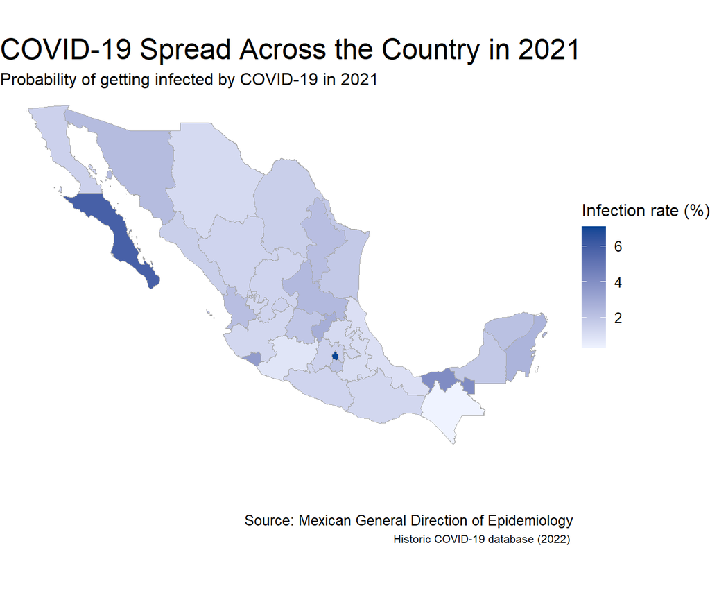

| State | Infection rate |
| --- | --- |
| Ciudad de México | 7.1 |
| Baja California Sur | 5.9 |
| Tabasco | 4.1 |
| Colima | 3.5 |
| Querétaro | 2.8 |
| Quintana Roo | 2.6 |

# **Tracing the evolution of a pandemic in 2021**

The year presented a series of challenges as COVID-19 cases surged, subsided, and resurged in various waves. The nation’s healthcare system, government, and communities tirelessly navigated through the ever-changing landscape, implementing a range of measures to contain the spread of the virus. The emergence of new variants, vaccination campaigns, and the impact on vulnerable populations were among the key milestones that shaped the pandemic’s trajectory. Through a comprehensive analysis of data and trends, this examination offers valuable insights into the progression of COVID-19 in Mexico throughout 2021. An average of the total cases a day was calculated as the inter-quantile range (IQR) for every month.

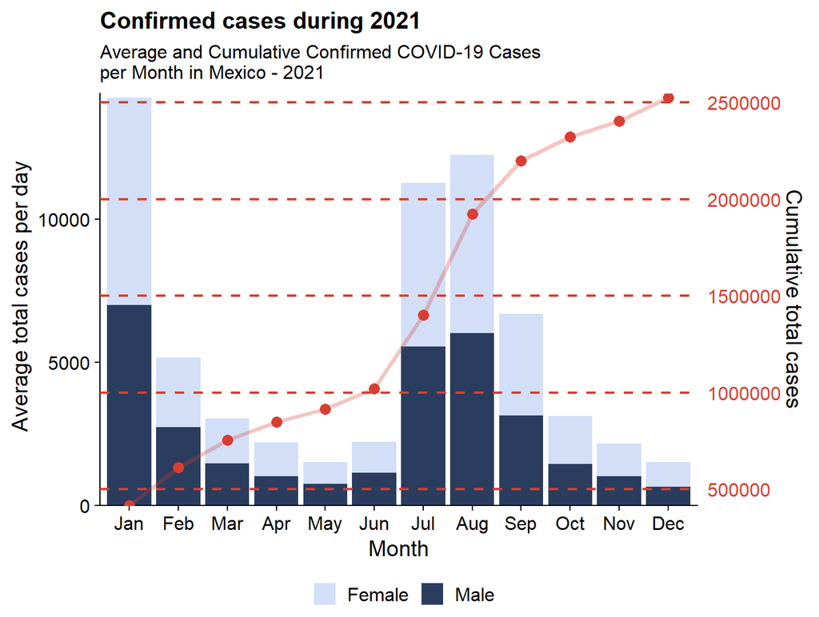

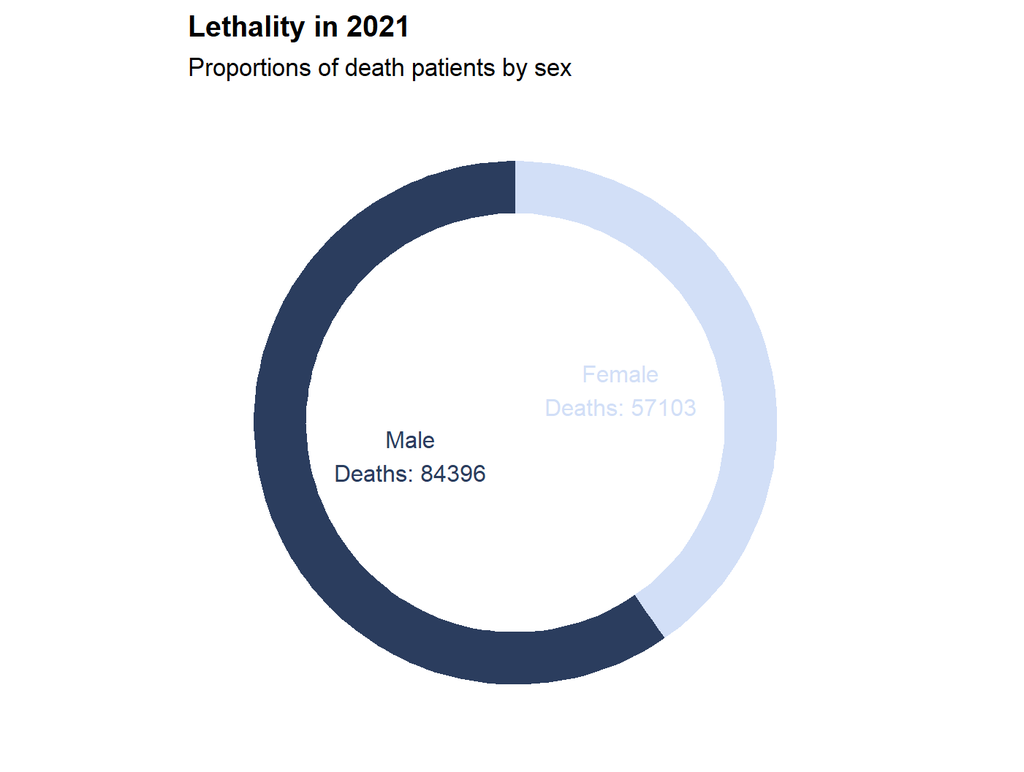

In 2021, the monthly distribution of COVID-19 cases showed similar patterns for both men and women. However, a notable distinction emerged regarding the number of deaths for each sex, with a significant difference observed *(p<0.05)*. The case fatality rate stood at 4.4% for females and 6.81% for males, indicating a substantial higher risk of mortality if infected with COVID-19 as a male in 2021. Nevertheless, it is essential to exercise caution when drawing conclusions, as individual patient factors leading to hospitalization and subsequent death may vary significantly. Therefore, it would be imprudent to make definitive assumptions based solely on gender when analyzing COVID-19 outcomes during this period.

# **The Age-Dependent Dichotomy: Ambulatory vs. Hospitalized Patients in the COVID-19 Landscape**

In Mexico during 2021, age played a crucial role in determining the likelihood of being hospitalized due to COVID-19. Older adults, particularly those above 65 years, faced higher chances of hospitalization compared to younger age groups. The elderly are more susceptible to severe outcomes because of age-related declines in the immune system and a higher prevalence of underlying health conditions. However, it is essential to note that hospitalization rates also depended on other factors such as vaccination status, regional variations in healthcare capacity, and adherence to public health measures. Here is a comparison between ambulatory and hospitalized cases by age group in Mexico 2021.

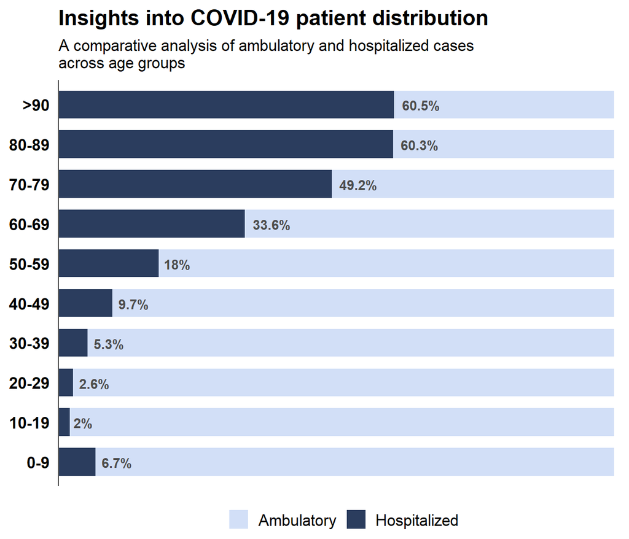

# **COVID-19 Mortality: Unveiling the Impact of Age on Fatality Risks**

The impact of age and pre-existing health conditions on the fatality of COVID-19 infections in Mexico was significant. Older adults, especially those aged 70 and above, faced a higher risk of severe outcomes and mortality due to age-related declines in immune function. Additionally, pre-existing health conditions such as cardiovascular diseases, diabetes, obesity, and respiratory disorders were key factors contributing to worse COVID-19 outcomes in Mexico. These conditions heightened the risk of complications and fatalities, placing individuals with such health concerns at a vulnerable position. In a general perspective, we can observe how the fatality rate increase as the patient’s age increase.

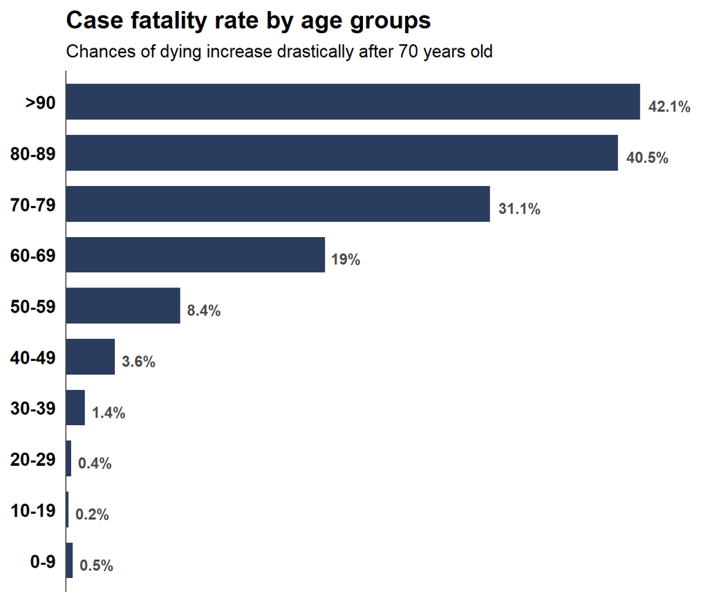

Despite the positive impact of vaccination efforts in reducing COVID-19 deaths compared to the pandemic’s onset in 2020, a deeper analysis reveals concerning trends. From a broad perspective, individuals aged 60 and above face nearly a 20% chance of mortality from COVID-19, and this risk escalates to 40% for those aged 80 and older. These statistics underscore the heightened vulnerability of older age groups to severe outcomes. Additionally, the relationship between mortality chances and pre-existing comorbidities becomes evident, as patients with multiple underlying health conditions face a higher risk of succumbing to the infection. Understanding and addressing these risk factors are crucial in implementing targeted measures to protect vulnerable populations and further curb the impact of COVID-19 on public health.

# **Unraveling the Connection: Age-Comorbilities relationship and their Influence on COVID-19 Mortality**

As the COVID-19 pandemic continues to impact communities worldwide, understanding the intricate relationship between age, comorbidities, and mortality becomes crucial for effective public health strategies. This project delves into the influence of age and pre-existing health conditions on COVID-19 mortality rates. We can see how the fatality rate changes depending on the age group and the number of comorbilities a patient has.

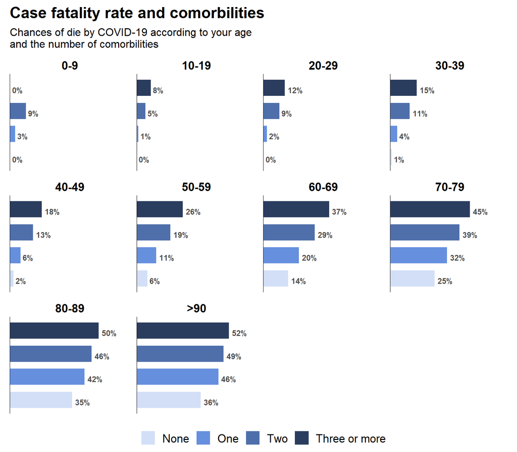

The findings from the analysis of the COVID-19 dataset in Mexico reveal a compelling and statistically significant relationship *(p<0.05)* between the probabilities of death or survival and two key factors: the number of comorbilities and the patient’s age group. The study demonstrated that patients with a higher number of comorbilities faced a significantly increased likelihood of death due to COVID-19, highlighting the critical impact of underlying health conditions on disease outcomes. Additionally, the results revealed a clear association between age and COVID-19 fatality rates, with older age groups showing a higher probability of death compared to younger counterparts. These findings underscore the importance of prioritizing vulnerable populations, particularly those with multiple comorbilities and older individuals, in public health measures and vaccination strategies to mitigate the severity of COVID-19 and safeguard those at the highest risk of adverse outcomes.